# Prezentacja metodologii

14 05 2020

## Wykorzystane zbiory danych

| Liczba Obserwacji | Liczba Kolumn | Procent braków danych | Balans Klas | Openml_ID |
| --- | --- | --- | --- | --- |
| 8844 | 55 | 7.16% | 94%/6% | 1018 |
| 48842 | 12 | 1.1% | 76%/24% | 1590 |
| 736 | 15 | 4.12% | 43%/57% | 188 |
| 500 | 12 | 15.92% | 58%/42% | 23381 |
| 368 | 19 | 17.15% | 63%/37% | 27 |
| 690 | 15 | 0.65% | 44%/56% | 29 |
| 3772 | 27 | 2.25% | 94%/6% | 38 |
| 57 | 16 | 35.75% | 35%/65% | 4 |
| 8378 | 122 | 1.82% | 84%/16% | 40536 |
| 45907 | 19 | 16.02% | 21%/79% | 41278 |
| 155 | 19 | 5.67% | 21%/79% | 55 |
| 435 | 16 | 5.63% | 61%/39% | 56 |
| 540 | 33 | 4.98% | 42%/58% | 6332 |
| 130 | 9 | 8.29% | 49%/51% | 944 |

## Podział zbirou na testowy i treningowy

Każdy zbiór był wstępnie czyszczony a następnie dzielony w sposób losowy na podzbiór treningowy i testowy:

- Zbiór treningowy **80%** obserwacji
- Zbiór testowy **20%** obserwacji

Podział pozostawał taki sam dla wszystkich metod imputacji i użytych modeli.

## Wykorzystane techniki imputacji braków danych

Przed przystąpieniem do imputacji usunęliśmy zmienną celu:

- Imputacja za pomocą **mediany** (14/14)
- Imputacja metodą z pakietu **mice** (13/14)
- Imputacja **missForest** (14/14)
- Imputacja **missMDA** (11/14)
- Imputacja **softImpute + mediana** (12/14)
- Imputacja funkcją **irmi** z pakietu **VIM** (11/14)

Po imputacji do zbioru ponownie dołączono kolumnę celu.

## Przebieg imputacji

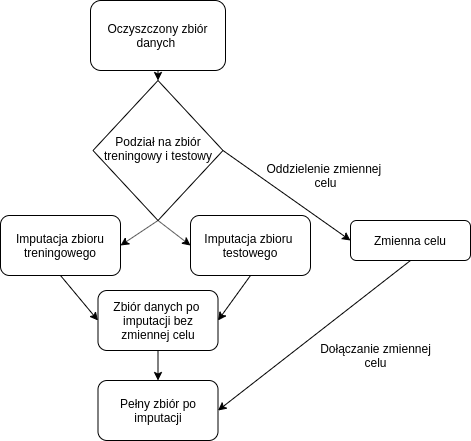

## Kodowanie zmiennych kategorycznych

Uzupełnione zbiory danych zawierają wiele zmiennych kategorycznych.  
Podejścia odrzucone:

- one-hot encoding
- ordinal encoding

Wybrane rozwiązanie:

- **target encoding**

Metoda kodowania jest uniwersalna i powszechnie używana.  
Dodatkowo usunięto w kilku zbiorach zmienne, które zawierały bardzo dużo unikalnych wartości.

## Kodowanie zmiennych kategorycznych

1. Zbiór podzielony na część treningową i testową
2. Wyliczenie parametrów **target encoding** na zbiorze treningowym
3. Kodowanie zmiennych w obu zbiorach

## Narzędzie do kodowania

Pakiet [H<sub>2</sub>O](https://docs.h2o.ai/h2o/latest-stable/h2o-docs/index.html) napisany w języku Java, udostępniający API dla R i python. Wykorzystuje obliczenia wielowątkowe.  
Kompletne narzędzie do uczenia maszynowego.  
Użyty moduł do target encoding:

- dodanie szumu
- średnie ważone względem liczności grup

## Wybrane algorytmy

Zbiory danych są gotowe do użycia przez modele uczenia maszynowego.  
Wykorzystane modele (*mlr name*):

- **regresja logistyczna**: *classif.glmnet*
- **las losowy**: *classif.ranger*
- **SVM**: *classif.svm*
- **XGBoost**: *classif.xgboost*

## Ewaluacja modeli

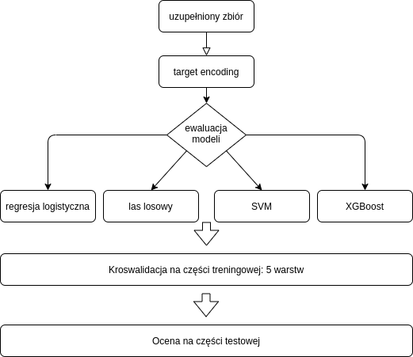

## Ewaluacja modeli

1. Podział zbiorów na część treningową i testową  
   jednakowy dla wszystkich modeli i metod imputacji
2. Podczas kroswalidacji strojenie parametrów modeli:
- **regresja logistyczna**: *alpha, nlambda*
- **las losowy**: *num.trees, min.node.size, mtry*
- **SVM**: *gamma*
- **XGBoost**: *eta, gamma, max_depth, subsample*

## Metryki ewaluacji

Jako podstawowy odnośnik

\(Accuracy = \frac{TP+TN}{TP+FP+FN+TN}\)

Uwzględniając niezbalansowanie części zbiorów

\(F1 = \frac{2\cdot precision \cdot recall}{precision+recall}\)

Gdzie:

- precision \(\frac{TP}{TP+FP}\)
- recall \(\frac{TP}{TP+FN}\)

## Wyniki

Jak opisaliśmy wcześniej zdecydowaliśmy się na użycie dwóch miar skuteczności algorytmów:

- F1 score
- Accuracy

Te dwie miary dobrze się uzupełniają, gdyż pozwalają dobrze zmierzyć skuteczności naszych imputacji oraz algorytmów zarówno na zbiorach zbalansowanych, jak i niezbalansowanych.

## Rozkład miary F1

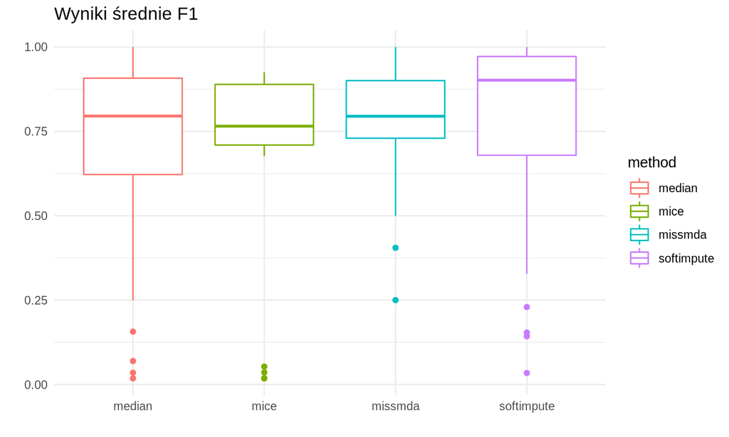

## Odchylenie standardowe F1

| method | F1_std |
| --- | --- |
| median | 0.2676632 |
| mice | 0.3303084 |
| missmda | 0.1716010 |
| softimpute | 0.2656013 |

## Rozkład miary Accuracy

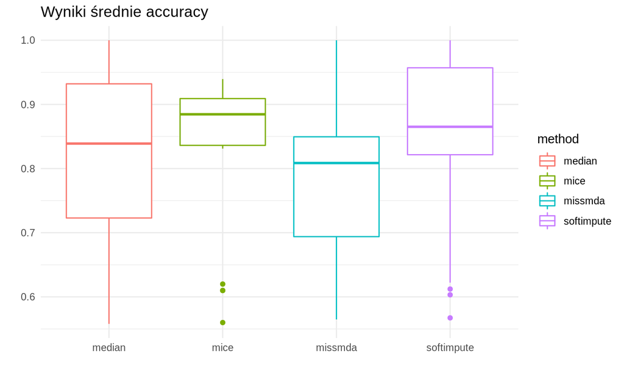

## Odchylenie standardowe Accuracy

| method | acc_std |
| --- | --- |
| median | 0.1243866 |
| mice | 0.1248682 |
| missmda | 0.1164327 |
| softimpute | 0.1200554 |

## Pierwsze wnioski

Na podstawie tych wykresów można wnioskować o ogólnych wynikach, jednkaże nie można się nimi sugerować zbyt bardzo, gdyż wyniki uzyskane przez algorytmy rożnią się w zależności od trudności zbioru a także od użytego algorytmu uczenia maszynowego. Sprawdźmy więc jak wyniki F1 różnią się w zależności od rodzaju imputacji oraz użytego algorytmu.

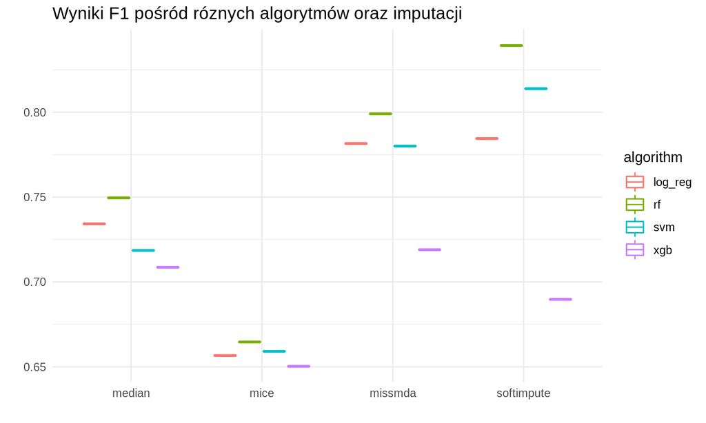

## Ranking metod

Jako bardziej wiarygodną próbę oceny skuteczności imputacji spróbujmy uszeregować je wedle następującego schematu. Weźmy wynik każdej z metod imputacji na każdym ze zbiorów. Wynik taki definiujemy jako średnia ze wszystkich algorytmów uczenia maszynowego puszczonych na danym zbiorze przy danej imputacji. Następnie sortujemy wynik od najwyższego i przyznajemy algorytmom punkty za każde miejsce. Końcowo punkty sumujemy a ta metoda imputacji, która punktów uzyska najmniej wygrwa nasz ranking.

| method | wynik |
| --- | --- |
| softimpute | 28 |
| median | 30 |
| mice | 32 |
| missmda | 38 |

Na podstawie tych wyników można wyciągnąc już dużo głębsze wnioski, dzięki możliwości rzetelnego porównania między sobą wyników uzyskanych przez algorytmy, na konkretnych zbiorach.

## Rankig imputacja + algorytm

Na podobnej zasadzie jak przed chwilą zdecydowaliśmy się poszukać najlepszej pary algorytm + imputacja

| method | algorithm | wynik |
| --- | --- | --- |
| softimpute | rf | 64 |
| median | rf | 88 |
| softimpute | log_reg | 92 |
| median | log_reg | 97 |
| median | xgb | 101 |
| missmda | rf | 114 |

## Kolejna forma rankingu

Jako drugą formę uszeregowania algorytmów imputacji zdecydowaliśmy się użyć następującej formuły. Traktujemy medianę jako podstawową formę imputacji i to do niej będziemy przyrównywać wszystkie pozostałe metody. Chcemy sprawdzić o ile średnio predykcje wykonane przez inne algorytmy różniły się od mediany. Jako jedną predykcję rozumiemy średnią ze wszystkich metod imputacji.

| method | score |
| --- | --- |
| missmda | 0.2831633 |
| softimpute | 0.1242047 |
| mice | -0.0124200 |

## Czasy

Kolejną płaszczyzną na której można porównywać algorytmy inputacji danych jest czas ich działania. Oczywistym jest, iż nawet najlepiej działający algorytm będzie nie do zaakceptowania, jeśli będzie działał zbyt długo.

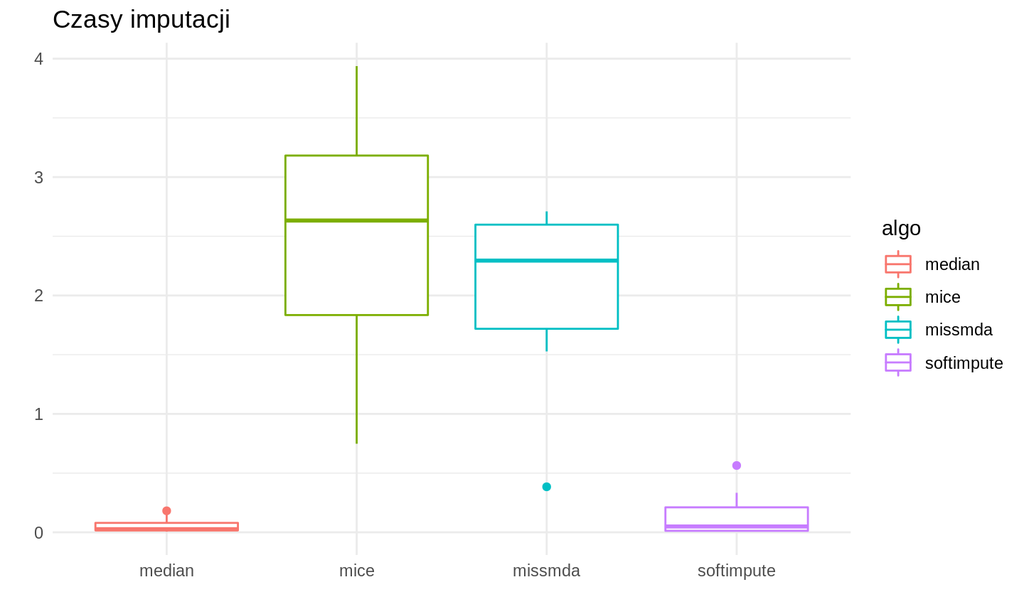